# Unit 4a: Probability Distributions with python

Here we will go over some probability distributions and show how to plot them in python

- You can get probability density functions and probability mass functions from scipy.stats
- You can *sample* from distributions using numpy.random
- I will also give you an idea how to do this stuff in R as well, later.
- make sure you have the plotting module **prob_dists.py** downloaded into your jupyter working directory,
- you will also need scipy (including matplotlib) and numpy to run. Also you may need python version 3.X

  Start with:

```python
import prob_dists
%matplotlib inline
```

## The Uniform discrete distribution

real world example: rolling dice

A random variable, $X$, is uniform-discrete distributed with integer parameter $N$ if it takes values $X=1,X=2,...,X=N$ with probabilities (pmf) given by

$P(X;N) = \frac{1}{N}$

The mean of $X$, and variance are

$E(X) = \frac{N+1}{2}$

$V(X) = \frac{N^2-1}{12}$

it is also possible to shift and scale this distribution to other ranges in which cases the above formulas have to be modified

you can plot the probability mass function with parameter N, by calling `dunif(N)` as shown below

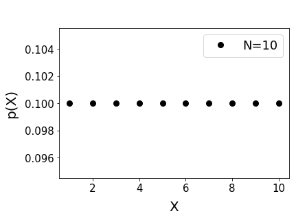

```python
prob_dists.dunif(10)
```

## The Binomial distribution

real world example: flipping a coin $n$, times with prob $p$ of success (heads), and count how many successes in the experiment

A random variable, $X$, is binomially distributed with integer parameter $n$ and real valued parameter $p \in [0,1]$ if it takes values $X=0,X=1,X=2,...,X=n$ with probabilities (pmf) given by

$P(X;n,p) = \frac{n!}{X!(n-X)!}p^X(1-p)^{n-X}$

The mean of $X$, and variance are

$E(X) = np$

$V(X) = np(1-p) = npq $

you can plot the probability mass function with parameter N, by calling `binomial(n,p)` as shown below

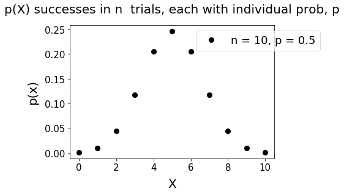

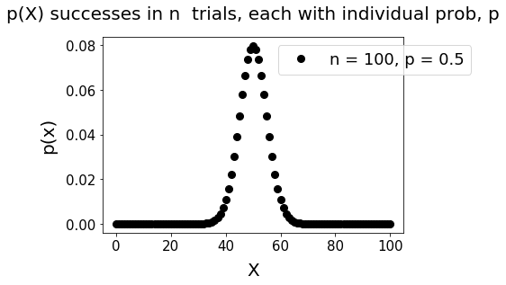

```python
prob_dists.binomial(10,0.5)
prob_dists.binomial(100,0.5)
```

## The Geometric distribution

real world example: number of times you need to gamble $x$, until first win, with each individual gamble prob = $p$ to win

A discrete random variable, $X$, is geometrically distributed with real valued parameter $p \in [0,1]$ if it takes values $X=1,X=2,...,X=\infty$ with probabilities (pmf) given by

$P(X;p) = p(1-p)^{X-1}$

The mean of $X$, and variance are

$E(X) = \frac{1}{p}$

$V(X) = \frac{1-p}{p^2}$

you can plot the probability mass function with parameter $p$, by calling `geometric(p)` as shown below

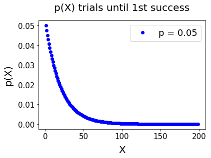

```python
prob_dists.geometric(0.05) # notice similary to exponential distribution!!
```

## The Poisson distribution

real world application: the poisson distribution describes *any* process where events occur **independently** with an average stationary rate, $\lambda$, of events per unit time or per unit space.

A random variable, $X$ is poisson distributed with parameter $\alpha$ if it takes discrete values, $X=0,X=1,X=2,...,X=\infty$, with probability mass function

$P(X;\alpha) = e^{-\alpha} \frac{\alpha^X}{X!}$

In order to understand the meaning of the rate $\alpha$ it is helpful to break it down into a product

$\alpha = \lambda t$

Where $\lambda$ is the expected number of events per unit time (say, minutes), and t is an *arbitrary time **interval*** $\sim [0,t]$ minutes

(note: alternatively you could say $\alpha = \lambda s$ where $s$ is a unit of distance or area etc. all the same considerations apply -- but lets use time here).

Then $\alpha$ is just the expected number of events *in the arbitrary chosen interval* .e.g. $\alpha$ depends on how big a time interval you choose to count the events over.

$\lambda = \frac{\textrm{# of events}}{1\textrm{ unit time}}$ is the expected number of events in *1 unit of time* which, on the other hand, doesn't depend on your chosen interval t.

Also, $\frac{1}{\lambda}$ is the average time **between** events and doesn't depend on how big a time interval you choose!!

Example: $\lambda = \frac{3\textrm{ events}}{1\textrm{ minute}}$

then $ \frac{1}{\lambda} = \frac{\textrm{0.333 minutes}}{1\textrm{ event}}$ or equivalently an average time of 0.33 minutes **between events**

It will be important that you understand this subtlety when we look at the exponential distribution. If we want to consider exponentially distributed interrarival times, then the associated poisson distributoin will have parameters that are inversely related since poisson talks about events per unit time (not flipped upside down!).

The mean of $X$, and variance are

$E(X) = \alpha$

$V(X) = \alpha$

you can plot the probability density function with parameter $\alpha =$ `a`, by calling `poiss(a)` as shown below

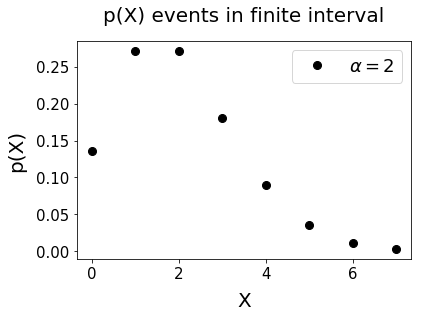

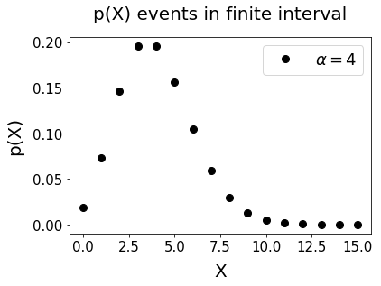

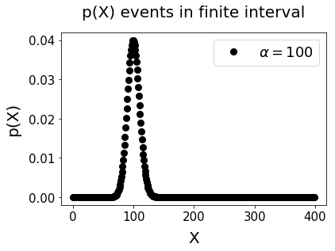

```python
prob_dists.poiss(2)
prob_dists.poiss(4)
prob_dists.poiss(100)
```

## The Hypergeometric distribution

real world example: calculating probabilities when playing cards

$p(X;N,K,n) = \frac{\binom{K}{k} \binom{N - K}{n-k}}{\binom{N}{n}}$

where

- $N$ is the population size,
- $K$ is the number of success states in the population,
- $n$ is the number of draws (i.e. quantity drawn in each trial) without replacement
- $X$ is the number of observed successes,
- $\textstyle {a \choose b}$ is a binomial coefficient

The mean of $X$, and variance are

$E(X) = n\frac{K}{N}$

$V(X) = n\frac{K}{N}\frac{(N-K)}{N}\frac{N-n}{N-1} $

you can plot the probability mass function with parameter $N,K$ and $n$, by calling `hyperg(N,K,n)` as shown below

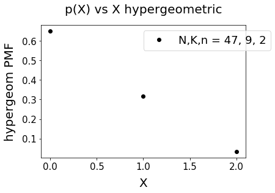

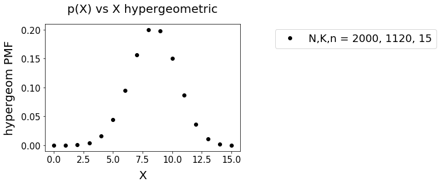

```python
prob_dists.hyperg(47,9,2)
prob_dists.hyperg(2000,1120,15)
```

## The power law distribution (Zipf)

real world example: the distribution of the frequencies of most common words (like 'the') in books. also, Benfords law

Formally, let:

$N$ be the number of elements, possibly infinite $X$ be their rank; $s$ be the value of the exponent characterizing the distribution.

Zipf's law then predicts that out of a population of N elements, the probability of elements of rank $X$, is:

$p(X;a,N)= \frac {1/k^{s}}{\sum \limits _{n=1}^{N}(1/n^{s})}$

Mean and variance require some calculation or lookup depending on the $N$, $s$ it can easily be obtained.

you can plot the probability density function with parameter `s`, by calling `zpf(s)` as shown below, also can plot on log-log axes with `loglog_zpf(lam)`

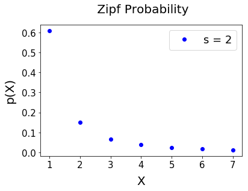

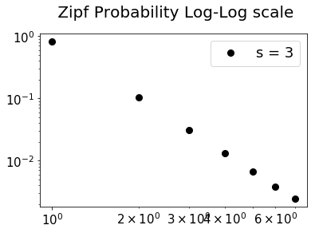

```python
prob_dists.zpf(2)
prob_dists.loglog_zpf(3)
```

## Continuous uniform distribution

real world example: waiting for the bus

$V(X) = \frac{(b-a)^2}{12}$

you can plot the probability density function with parameters $a,b$, by calling `cunif(a,b)` as shown below,

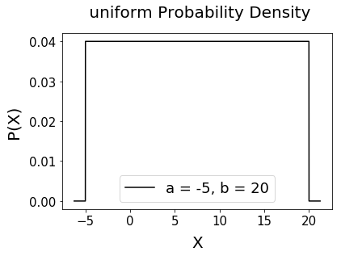

```python
prob_dists.cunif(-5,20)
```

## Triangular distribution

real world example: maximum ignorance model with a known mode and lower, upper limits, predicting sales

The mean of $X$, and variance are

$E(X) = \frac{l + m + r}{3}$

$V(X) = \frac{l^2 + m^2 + r^2-lm-lr-rm}{18}$

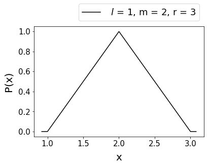

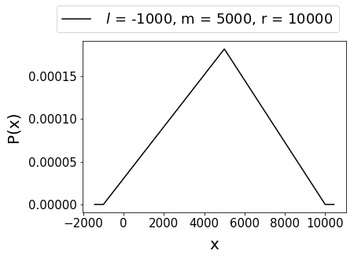

```python
prob_dists.triangle(1,2,3)
prob_dists.triangle(-1000,5000,10000)
```

## The normal distribution

This is kind of like the mother of all distributions, due to a result called the *central limit theorem*. This theorem states that the mean of any set of variates with any distribution having a finite mean and variance tends to the normal distribution. Many common attributes such as test scores, height, etc., follow roughly normal distributions, with few members at the high and low ends and many in the middle. The binomial and poisson distributions tend to normal distributions in some limits.

Importantly, we will see that the **sample mean** follows a normal distribution (as already discussed with reference to the standard error of the mean SEM, as well).

A random variable, $X$ is normally distributed $\sim N(\mu,\sigma^2)$ if it takes values with probability density

$P(X; \mu, \sigma^2) = \frac{1}{\sqrt{2\pi\sigma^2} } e^{ -\frac{(x-\mu)^2}{2\sigma^2} }$ for $ -\infty \gt X \lt \infty$

The mean of $X$, and variance are

$E(X) = \mu$

$V(X) = \sigma^2$

you can plot the probability density function with parameters $\mu$ and **$\sigma$** (*not* $\sigma^2$) by calling `normal(mu,sigma)` as shown below,

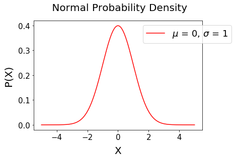

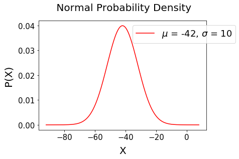

```python
prob_dists.normal(0,1)
prob_dists.normal(-42,10)
```

## the log-normal distribution

Kind of like the normal distribution, but gathered from the *product* of many independent random variables instead of the sum.

It is important to not that many real world things are log-normally distributed for example the frequency of purchasing of commercial items follows a log-normal distribution. For example if you create a histogram of the percent of the population who buy toothpaste once, twice, three times, etc. per year, you will find that the people follow a log-normal distribution for this (source: my friend who works at a a credit card company analyzing purchases).

Notice that $X$ can only take values more than 0. That's another reason it is sometimes better for modelling stuff than the regular plain vanilla normal distribution.

A random variable, $X$ is log-normally distributed if it takes values with probability density

$P(X; \mu, \sigma^2) = \frac{1}{x\sqrt{2\pi\sigma^2} } e^{ -\frac{(\ln{x}-\mu)^2}{2\sigma^2} }$ for $ 0 \gt X \lt \infty$

The mean of $X$, and variance are

$V(X) = \sigma^2$

you can plot the probability density function with parameters $\mu$ and **$\sigma$** (*not* $\sigma^2$) by calling `lognormal(mu,sigma)` as shown below,

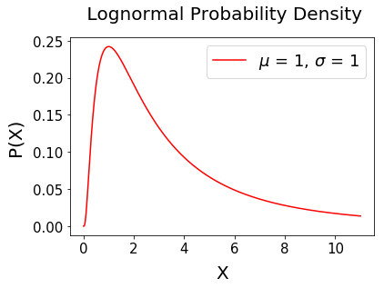

```python
prob_dists.lognormal(1,1)
```

## The exponential distribution

A random variable, $X$ is exponentially distributed with parameter $\lambda$ if it takes values with probability density

$P(X;\lambda) = \lambda \exp(-\lambda)$

The mean of $X$, and variance are

$E(X) = \frac{1}{\lambda}$

$V(X) = \frac{1}{\lambda^2}$

you can plot the probability density function with parameter $\lambda =$ `lam`, by calling `expo(lam)` as shown below, also can plot on semi log axes with `semilog_expo(lam)`

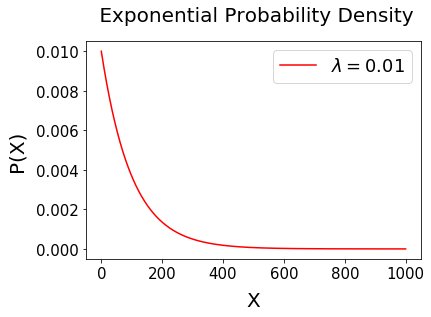

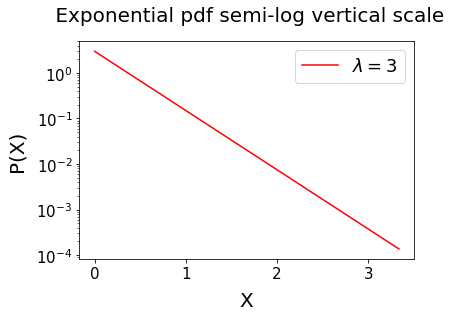

```python
prob_dists.expo(0.01)
prob_dists.semilog_expo(3)
```

## Memorylessness (Markov) property of the exponential distribution

proof on the chalkboard

## Empirical Distributions

- This by no means covers the many different types of probability distributions that things can follow.
- Remember, probability distributions just tell you how likely it is for a random thing to occur. Looking at the probability distribution tells you what numbers, $X$, are more likely or less likely to occur.
- Often times, real world data doesn't exactly follow any of the distributions above.
- You can get probability distributions just by creating a normalized histogram of your data

## Drawing Samples

We can draw samples from any of these distributions (and more!) in python using `numpy.random.distribution(parameters,size)`

where `size` is the number of samples you want to draw and `distribution` could be normal, exponential, binomial, with `parameters` that depend on what shape you want to draw from, for example:

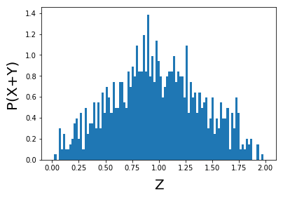

```python
import numpy as np
import matplotlib.pyplot as plt

size = 1000

X = np.random.random(size) # this gives you 1000 numbers between [0,1]
Y = np.random.random(size) # # this gives you another 1000 numbers between [0,1]

Z = X + Y;    # the results should lie on the interval [0,2]

fig, ax = plt.subplots()
ax.set_xlabel("Z",fontsize=20)
ax.set_ylabel("P(X+Y)",fontsize=20)
ax.hist(Z, bins=np.linspace(0, 2.0, 100),density=True );  #semi-colon supresses unwanted output
```

## CDF and Quantiles functions

In addition to being able to sample, Python also gives you access to the cumulative distribution and quantile functions of all of the above distributions

- the CDF is obtained through `.cdf`
- the quantiles are obtained through the `.ppf`

Examples are below

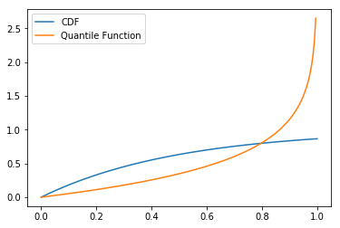

```python
import scipy
import numpy as np
import matplotlib as mpl
import matplotlib.pyplot as plt

# Example with the exponential distribution
c = 0
lamb = 2

# Create a frozen exponential distribution instance with specified parameters
exp_obj = scipy.stats.expon(c,1/float(lamb))

x_in = np.linspace(0,1,200) # 200 numbers in [0,1], input for ppf()
y_out = exp_obj.ppf(x_in)
y_cdf = exp_obj.cdf(x_in)
plt.plot(x_in,y_cdf,label="CDF") # graphically check the results of the CDF
plt.plot(x_in,y_out,label='Quantile Function') # graphically check the results of the inverse CDF
plt.legend();
```

## R

Now we will switch gears and quickly learn how to do things in R as well, you can refer back to this document for formulas and python implementations